# 22894_MY472_FinalAssignment

2023-12-16

GitHub Repository: https://github.com/brunoschef/MY472_FinalAssignment

Members of Parliament (MPs) in the UK use parliamentary questions as mechanisms to query the government on a wide range of issues. This project analyses whether there are factors differentiating MPs that tend to table questions to HM Treasury (economic issues), The Department of Health and Social Care, and The Department of Work and Pensions (welfare issues). Analysis will focus on the following factors: the degree of marginality in the 2019 election, political party, median wage in the MPs constituency, and whether the MP represents a devolved nation (Scotland, Wales or Northern Ireland).

The UK Parliament API was used to collect information on oral and written questions, including the name of the MP tabling the question, that MP’s constituency and party, which Government department answered the question, and whether it was a written or oral question. All questions were collected in the same time frame (from May 2022). Further data, including the MPs 2019 majority and their constituency’s coordinates were scraped from Wikipedia. Lastly, the median weekly wage in each constituency was collected from pre-existing data published by the House of Commons Library. All of these data sources were combined into one table that was written to a relational database. This allowed the data to be easily accessed and the web scrapers to only be run once, rather than every time the document is knitted.

Below are the counts of categorical variables of interest and summary statistics for numeric variables:

## Answering Body Summary

| answeringbody | count |
| --- | --- |
| Department for Work and Pensions | 300 |
| Department of Health and Social Care | 300 |
| Treasury | 300 |

## Question Type Summary

| type | count |
| --- | --- |
| oral | 300 |
| written | 600 |

## Party Summary

| party | count |
| --- | --- |
| Alba Party | 7 |
| Alliance | 4 |
| Conservative | 240 |
| Democratic Unionist Party | 20 |
| Green Party | 4 |
| Independent | 15 |
| Labour | 504 |
| Liberal Democrat | 35 |
| Plaid Cymru | 8 |
| Scottish National Party | 57 |
| Social Democratic & Labour Party | 4 |
| The Reclaim Party | 2 |

## Has Devolved Parliament Summary

| has_devolved_parl | count |
| --- | --- |
| No | 727 |
| Yes | 173 |

## Nation Summary

| nation | count |
| --- | --- |
| England | 727 |
| Northern Ireland | 28 |
| Scotland | 83 |
| Wales | 62 |

## Numeric Variables Summary

|  | majority | WageMedianConst |
| --- | --- | --- |
|  | Min. : 145 | Min. : 517.0 |
|  | 1st Qu.: 5426 | 1st Qu.: 623.0 |
|  | Median : 9254 | Median : 671.0 |
|  | Mean :11211 | Mean : 689.4 |
|  | 3rd Qu.:15401 | 3rd Qu.: 728.0 |
|  | Max. :39942 | Max. :1049.0 |
|  | NA’s :118 | NA’s :4 |

As seen above, there are 300 questions asked to each government department. Out of the total 900 questions, 600 are written questions and 300 are oral questions. The majority of questions are tabled by Conservative or Labour MPs, with several also coming from the Scottish National Party (SNP) and the Liberal Democrats. 173 of the 900 total questions were tabled by MPs from countries with devolved parliaments (83 from Scotland, 62 from Wales, and 28 from Northern Ireland). The mean value for parliamenrtaray majority is 11,211 with a very large spread, while the mean for median weekly wage is 689.4.

Below in Figure 1 is a visualization of where in the UK questions are being tabled from, where color is coded by answering body:

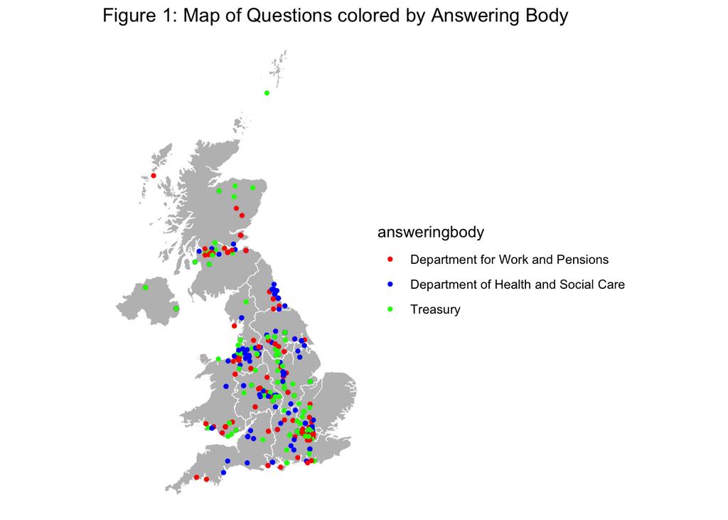

The points seem generally clustered in highly populated areas, which is expected, as there are more constituencies in urban areas. It appears that questions are asked to the three departments at roughly equal rates across most of the country. The exception to this is in the devolved nations, where it seems that DHSC questions could be asked at slightly lower rates. This would make sense, as the NHS in these countries is run by the devolved governments, and it is likely that members of their respective parliaments would deal with a greater number of health-related queries than MPs.

Below is the output of a multinomial logistic regression model exploring the relationship between the variables of interest:

| y.level | term | estimate | std.error | statistic | p.value |
| --- | --- | --- | --- | --- | --- |
| Department for Work and Pensions | (Intercept) | 1.2283445 | 0.0000003 | 4.068349e+06 | 0.0000000 |
| Department for Work and Pensions | partyAlba Party | -0.0856607 | 0.0000000 | -1.137112e+07 | 0.0000000 |
| Department for Work and Pensions | partyAlliance | -15.9580511 | 0.0000000 | -2.789245e+15 | 0.0000000 |
| Department for Work and Pensions | partyDemocratic Unionist Party | -0.9919645 | 0.0000000 | -7.281950e+07 | 0.0000000 |
| Department for Work and Pensions | partyGreen Party | 0.0000000 | 0.0000000 | 0.000000e+00 | 1.0000000 |
| Department for Work and Pensions | partyIndependent | -0.9734590 | 0.0000000 | -1.173272e+08 | 0.0000000 |
| Department for Work and Pensions | partyLabour | 0.3696601 | 0.0000001 | 2.993385e+06 | 0.0000000 |
| Department for Work and Pensions | partyLiberal Democrat | 0.3607488 | 0.0000000 | 1.192331e+07 | 0.0000000 |
| Department for Work and Pensions | partyPlaid Cymru | -2.2001166 | 0.0000000 | -6.099050e+08 | 0.0000000 |
| Department for Work and Pensions | partyScottish National Party | 0.1259456 | 0.0000001 | 2.356630e+06 | 0.0000000 |
| Department for Work and Pensions | partySocial Democratic & Labour Party | -0.5270615 | 0.0000000 | -1.674338e+09 | 0.0000000 |
| Department for Work and Pensions | partyThe Reclaim Party | -13.6806298 | 0.0000000 | -4.229357e+15 | 0.0000000 |
| Department for Work and Pensions | WageMedianConst | -0.0012698 | 0.0002201 | -5.769034e+00 | 0.0000000 |
| Department for Work and Pensions | majority | -0.0000463 | 0.0000121 | -3.822896e+00 | 0.0001319 |
| Department for Work and Pensions | has_devolved_parlYes | 0.2441897 | 0.0000001 | 1.692363e+06 | 0.0000000 |
| Department of Health and Social Care | (Intercept) | 1.0570285 | 0.0000003 | 3.569465e+06 | 0.0000000 |
| Department of Health and Social Care | partyAlba Party | 1.3303540 | 0.0000000 | 2.388574e+08 | 0.0000000 |
| Department of Health and Social Care | partyAlliance | -13.0552373 | 0.0000000 | -7.414788e+14 | 0.0000000 |
| Department of Health and Social Care | partyDemocratic Unionist Party | -0.5649593 | 0.0000000 | -1.029851e+08 | 0.0000000 |
| Department of Health and Social Care | partyGreen Party | 0.0000000 | 0.0000000 | NaN | NaN |
| Department of Health and Social Care | partyIndependent | 0.9394406 | 0.0000000 | 8.097459e+07 | 0.0000000 |
| Department of Health and Social Care | partyLabour | 0.6063303 | 0.0000002 | 4.025200e+06 | 0.0000000 |
| Department of Health and Social Care | partyLiberal Democrat | 0.9351334 | 0.0000000 | 3.141680e+07 | 0.0000000 |
| Department of Health and Social Care | partyPlaid Cymru | -0.5783950 | 0.0000000 | -1.464380e+08 | 0.0000000 |
| Department of Health and Social Care | partyScottish National Party | 0.7122310 | 0.0000000 | 2.854433e+07 | 0.0000000 |
| Department of Health and Social Care | partySocial Democratic & Labour Party | 0.6901912 | 0.0000000 | 5.563651e+08 | 0.0000000 |
| Department of Health and Social Care | partyThe Reclaim Party | -14.4908158 | 0.0000000 | -1.190843e+16 | 0.0000000 |
| Department of Health and Social Care | WageMedianConst | -0.0016260 | 0.0002187 | -7.433837e+00 | 0.0000000 |
| Department of Health and Social Care | majority | 0.0000030 | 0.0000102 | 2.946956e-01 | 0.7682264 |
| Department of Health and Social Care | has_devolved_parlYes | -1.3022330 | 0.0000001 | -1.849394e+07 | 0.0000000 |

Due to small counts for many parties, analysis will focus on the four largest parties, the Conservatives, Labour, Liberal Democrats and the SNP. It appears that MPs in the Labour Party, Liberal Democrats, and SNP have higher log odds relative to Conservatives of tabling a DWP question compared to a Treasury question. The same is observed for Health and Social Care, with similarly increased log odds (positive estimate and p < 0.05). In other words, there is evidence to suggest that party affiliation is associated with differences in the government department to which an MP asks a question.

Additionally, for every one unit increase in median constituency wage, MPs have lower log odds of asking a question to DPW compared to HM Treasury. Once again this is observed for Health and Social Care. Size of majority did not return a significant result for DHSC, but it did for DPW; it seems that MPs with larger majorities have lower log odds of asking a DPW question compared to a Treasury question. Lastly, MPs representing a devolved nation have lower log odds of asking a question to DHSC compared to HM Treasury. This adds evidence to the hypothesis that MPs from Wales, Scotland and Northern Ireland engage less in Westminster with issues that are devolved.

In summary, the spatial visualisation and the findings of the multinomial logistic regression model show that factors discriminating whether MPs tend to ask questions relating to economic, health, or welfare issues include party affiliation, median wage in the Member’s constituency, whether they represent a devolved nation, and the size of their majority.

**Code appendix**

```r
knitr::opts_chunk$set(echo=FALSE, warning=FALSE, message=FALSE, eval=FALSE)
# Load libary
library(httr)

# Set API link for written questions to HM Treasury
treasurypqurl <- "https://questions-statements-api.parliament.uk/api/writtenquestions/questions?tabledWhenFrom=2022-05-10&answered=Any&expandMember=true&includeWithdrawn=false&answeringBodies=14&house=Commons&take=200"

# Get the data
treasurypqdata <- GET(treasurypqurl)

# Parse the data
treasurypq <- content(treasurypqdata, "parsed")

# Clean to get just the desired variables of interest
treasurypq <- lapply(treasurypq$results, function(sub_element) unlist(sub_element$value))

treasurypq <- lapply(treasurypq, function(observation) {
  list(
    askingMember.name = observation[[5]],
    askingMember.party = observation[[6]],
    askingMember.memberFrom = observation[[9]],
    dateTabled = observation[[13]],
    questionText = observation[[16]],
    answeringBodyName = observation[[18]]
  )
})

# Set API link for written question to the Department of Health and Social Care
dhscpqurl <- "https://questions-statements-api.parliament.uk/api/writtenquestions/questions?tabledWhenFrom=2022-05-10&answered=Any&expandMember=true&includeWithdrawn=false&answeringBodies=17&house=Commons&take=200"

# Get the data
dhscpqdata <- GET(dhscpqurl)

# Parse the data
dhscpq <- content(dhscpqdata, "parsed")

# Clean to get just the desired variables of interest
dhscpq <- lapply(dhscpq$results, function(sub_element) unlist(sub_element$value))

dhscpq <- lapply(dhscpq, function(observation) {
  list(
    askingMember.name = observation[[5]],
    askingMember.party = observation[[6]],
    askingMember.memberFrom = observation[[9]],
    dateTabled = observation[[13]],
    questionText = observation[[16]],
    answeringBodyName = observation[[18]]
  )
})

# Set API link for written questions to the Department of Work and Pensions
dwppqurl <- "https://questions-statements-api.parliament.uk/api/writtenquestions/questions?tabledWhenFrom=2022-05-10&answered=Any&expandMember=true&includeWithdrawn=false&answeringBodies=29&house=Commons&take=200"

# Get the data
dwppqdata <- GET(dwppqurl)

# Parse the data
dwppq <- content(dwppqdata, "parsed")

# Clean to get just the desired variables of interest
dwppq <- lapply(dwppq$results, function(sub_element) unlist(sub_element$value))

dwppq <- lapply(dwppq, function(observation) {
  list(
    askingMember.name = observation[[5]],
    askingMember.party = observation[[6]],
    askingMember.memberFrom = observation[[9]],
    dateTabled = observation[[13]],
    questionText = observation[[16]],
    answeringBodyName = observation[[18]]
  )
})

# Combine the three written questions lists into one list
all_lists <- list(treasurypq, dhscpq, dwppq)

# Initialize an empty data frame
pq_df <- data.frame(matrix(ncol = 6, nrow = 0))

# Loop through each list and bind rows to the data frame
for (current_list in all_lists) {
  for (observation in current_list) {
    pq_df <- rbind(pq_df, unlist(observation))
  }
}

# Add column names
colnames(pq_df) <- c("membername", "party", "constituency", "datetabled", "questiontext", "answeringbody")

# Add a column for question type
pq_df$type <- 'written'

# Set API link for oral questions to HM Treasury
treasuryoqurl <- "https://oralquestionsandmotions-api.parliament.uk/oralquestions/list?parameters.answeringDateStart=2022-05-10&parameters.answeringBodyIds=14&parameters.take=100"

# Get the data
treasuryoqdata <- GET(treasuryoqurl)

# Parse the data
treasuryoq <- content(treasuryoqdata, "parsed")

# Clean to get just the desired variables of interest
treasuryoq <- treasuryoq$Response

treasuryoq <- lapply(treasuryoq, function(observation) {
  list(
    askingMember.name = observation[[15]][[3]],
    askingMember.party = observation[[15]][[7]],
    askingMember.memberFrom = observation[[15]][[5]],
    dateTabled = observation[[6]],
    questionText = observation[[3]],
    answeringBodyName = observation[[13]]
  )
})

# Set API link for oral questions to the Department of Health and Social Care
dhscoqurl <- "https://oralquestionsandmotions-api.parliament.uk/oralquestions/list?parameters.answeringDateStart=2022-05-10&parameters.answeringBodyIds=17&parameters.take=100"

# Get the data
dhscoqdata <- GET(dhscoqurl)

# Parse the data
dhscoq <- content(dhscoqdata, "parsed")

# Clean to get just the desired variables of interest
dhscoq <- dhscoq$Response

dhscoq <- lapply(dhscoq, function(observation) {
  list(
    askingMember.name = observation[[15]][[3]],
    askingMember.party = observation[[15]][[7]],
    askingMember.memberFrom = observation[[15]][[5]],
    dateTabled = observation[[6]],
    questionText = observation[[3]],
    answeringBodyName = observation[[13]]
  )
})

# Set API link for oral questions to the Department of Work and Pensions
dwpoqurl <- "https://oralquestionsandmotions-api.parliament.uk/oralquestions/list?parameters.answeringDateStart=2022-05-10&parameters.answeringBodyIds=29&parameters.take=100"

# Get the data
dwpoqdata <- GET(dwpoqurl)

# Parse the data
dwpoq <- content(dwpoqdata, "parsed")

# Clean to get just the desired variables of interest
dwpoq <- dwpoq$Response

dwpoq <- lapply(dwpoq, function(observation) {
  list(
    askingMember.name = observation[[15]][[3]],
    askingMember.party = observation[[15]][[7]],
    askingMember.memberFrom = observation[[15]][[5]],
    dateTabled = observation[[6]],
    questionText = observation[[3]],
    answeringBodyName = observation[[13]]
  )
})

# Combine the three lists for oral questions into one list
all_lists_oral <- list(treasuryoq, dhscoq, dwpoq)

# Initialize an empty data frame
oq_df <- data.frame(matrix(ncol = 6, nrow = 0))

# Loop through each list and bind rows to the data frame
for (current_list in all_lists_oral) {
  for (observation in current_list) {
    oq_df <- rbind(oq_df, unlist(observation))
  }
}

# Add column names
colnames(oq_df) <- c("membername", "party", "constituency", "datetabled", "questiontext", "answeringbody")
```

```r
# Add column for type of question
oq_df$type <- 'oral'

library(dplyr)

# Combine the written questions data frame and the oral questions data frame
questionsdata <- rbind(pq_df, oq_df)

# Get data on median earnings in each constituency, clean and merge with main questions data frame
constituencyearnings <- read.csv("constituencyearnings.csv")

constituencyearnings <- subset(constituencyearnings, select = c("ConstituencyName", "WageMedianConst"))

constituencyearnings <- constituencyearnings %>%
  rename(constituency = ConstituencyName)

questionsdata <- merge(questionsdata, constituencyearnings, by = "constituency", all.x = TRUE)

# Convert wage to numeric
questionsdata$WageMedianConst <- as.numeric(questionsdata$WageMedianConst)

# Scrape wikipedia to get data on each MPs majority in the 2019 general election
library(rvest)

genelecurl <- "https://en.wikipedia.org/wiki/Results_of_the_2019_United_Kingdom_general_election"
html_elect <- read_html(genelecurl)

# Get constituency data
constituency <- html_elect %>%
  html_nodes("table.wikitable td:nth-child(1) > a") %>%
  html_text()

# Get majority data for England
engmajority <- html_elect %>%
  html_nodes("table.wikitable:nth-of-type(1) td:nth-child(10)") %>%
  html_text()

#Get majority data for NI and removing errant data
nimajority <- html_elect %>%
  html_nodes("table.wikitable:nth-of-type(2) td:nth-child(8)") %>%
  html_text()
nimajority <- nimajority[1:18]

# Get majority data for Scotland and removing errant data
scotlandmajority <- html_elect %>%
  html_nodes("table.wikitable:nth-of-type(3) td:nth-child(8)") %>%
  html_text()
scotlandmajority <- scotlandmajority[1:59]

# Get majority data for Wales
walesmajority <- html_elect %>%
  html_nodes("table.wikitable:nth-of-type(4) td:nth-child(9)") %>%
  html_text()

# Combine all majority data into one vector
majority <- c(engmajority, nimajority, scotlandmajority, walesmajority)
majority <- gsub("\n", "", majority)
majority <- gsub(",", "", majority)

majority <- as.numeric(majority)

# Combine all data into one dataframe and combine into overall questions data frame
electiondata <- data.frame(constituency, majority)

questionsdata <- merge(questionsdata, electiondata, by = "constituency", all.x = TRUE)

# Get coordinates of each constituency to do spatial analysis and merge into overall data frame
constituencies <- unique(questionsdata$constituency)
formatted_constit <- gsub(" ", "_", constituencies)
formatted_constit <- paste0(formatted_constit, "_")

coords <- tibble(constituency = constituencies, coordinates = NA)
total_const <- length(formatted_constit)

for (i in seq_along(formatted_constit)) {
  current_constituency <- formatted_constit[i]

  # Get the full URL of the current constituency's Wikipedia page
  current_url <- paste("https://en.wikipedia.org/wiki/", current_constituency, "(UK_Parliament_constituency)", sep = "")

  current_html <- read_html(current_url)

  # Get the coordinates of the constituency
  coordinates <- current_html %>% html_elements(css = "span.geo-dec") %>% html_text()

  # Add NA if there are no coordinates available
  if (length(coordinates) == 0) {
    coordinates <- NA
  }

  # Add the coordinates to the dataframe
  coords$coordinates[i] <- coordinates

  percent_done <- (i / total_const) * 100
  cat(sprintf("Progress: %.2f%%\r", percent_done))
  flush.console()

    # Wait half a second before next request
  Sys.sleep(0.5)
}

questionsdata <- merge(questionsdata, coords, by = "constituency", all.x = TRUE)

# Get data on which nation the MP's constituency is in
constituenciesurl <- "https://en.wikipedia.org/wiki/List_of_United_Kingdom_Parliament_constituencies"
html_constituencies <- read_html(constituenciesurl)

# Get data on which nation the MP's constituency is in
england <- html_constituencies %>%
  html_nodes("table.wikitable:nth-of-type(5) td:nth-child(1) > a") %>%
  html_text()

scotland <- html_constituencies %>%
  html_nodes("table.wikitable:nth-of-type(6) td:nth-child(1) > a") %>%
  html_text()

wales <- html_constituencies %>%
  html_nodes("table.wikitable:nth-of-type(7) td:nth-child(1) > a") %>%
  html_text()

ni <- html_constituencies %>%
  html_nodes("table.wikitable:nth-of-type(8) td:nth-child(1) > a") %>%
  html_text()

# Create new column in overall questions dataset titled 'nation'
questionsdata$nation <- NA

# Fill in the nation column with the appropriate nation
questionsdata$nation[questionsdata$constituency %in% england] <- "England"
questionsdata$nation[questionsdata$constituency %in% scotland] <- "Scotland"
questionsdata$nation[questionsdata$constituency %in% wales] <- "Wales"
questionsdata$nation[questionsdata$constituency %in% ni] <- "Northern Ireland"

# Create new column in overall dataset titled 'has_devolved_parl' indicating whether an MP represents an area with a devolved parliament
questionsdata$has_devolved_parl <- NA

# Fill in the has_devolved_parl column with the appropriate value
questionsdata$has_devolved_parl[questionsdata$nation == "England"] <- 'No'
questionsdata$has_devolved_parl[questionsdata$nation == "Northern Ireland"] <- 'Yes'
questionsdata$has_devolved_parl[questionsdata$nation == "Scotland"] <- 'Yes'
questionsdata$has_devolved_parl[questionsdata$nation == "Wales"] <- 'Yes'

# Write final table to a relational database (note: this means all cells scraping can be set to eval=FALSE in the R markdown, to avoid re-scraping websites every time the document is knitted)
library(DBI)
final_db <- dbConnect(RSQLite::SQLite(), "MY472_FinalAssignment.sqlite")
file.exists("MY472_FinalAssignment.sqlite")

dbWriteTable(final_db, "questionsdata", questionsdata, overwrite = TRUE)

library(DBI)

#Connect to relational database
final_db <- dbConnect(RSQLite::SQLite(), "MY472_FinalAssignment.sqlite")

# Call table in relational database
questionsdf <- dbGetQuery(final_db,
                            "SELECT *
                            FROM questionsdata")

library(dplyr)
library(tidyr)
library(knitr)
library(kableExtra)
```

```r
# Create a summary table for answeringbody
answeringbody_summary <- questionsdf %>%
  count(answeringbody) %>%
  rename(count = n)

cat("<div style='text-align: center;'>")
cat("<h2 style='font-size: 18px;'>Answering Body Summary</h2>")
kable(answeringbody_summary, format = "html") %>%
  kable_styling(full_width = FALSE)

# Add some space between tables
cat("<br>")

# Create a summary table for type of question
questiontype_summary <- questionsdf %>%
  count(type) %>%
  rename(count = n)

cat("<h2 style='font-size: 18px;'>Question Type Summary</h2>")
kable(questiontype_summary, format = "html") %>%
  kable_styling(full_width = FALSE)

cat("<br>")

# Create a summary table for party
party_summary <- questionsdf %>%
  count(party) %>%
  rename(count = n)

cat("<h2 style='font-size: 18px;'>Party Summary</h2>")
kable(party_summary, format = "html") %>%
  kable_styling(full_width = FALSE)

cat("<br>")

# Create a summary table for hasdevolvedparl
hasdevolvedparl_summary <- questionsdf %>%
  count(has_devolved_parl) %>%
  rename(count = n)

cat("<h2 style='font-size: 18px;'>Has Devolved Parliament Summary</h2>\n")
kable(hasdevolvedparl_summary, format = "html") %>%
  kable_styling(full_width = FALSE)

cat("<br>")

# Create a summary table for nation
nation_summary <- questionsdf %>%
  count(nation) %>%
  rename(count = n)

cat("<h2 style='font-size: 18px;'>Nation Summary</h2>")
kable(nation_summary, format = "html") %>%
  kable_styling(full_width = FALSE)

cat("<br>")

# Create a table with summary statistics for the numeric variables
numeric_summary <- questionsdf %>%
  select(majority, WageMedianConst) %>%
  summary()

cat("<h2 style='font-size: 18px;'>Numeric Variables Summary</h2>")
cat("</div>")
kable(numeric_summary, format = "html") %>%
  kable_styling(full_width = FALSE)

cat("<br>")

## SPATIAL ANALYSIS/VISUALISATION
library(sf)
library(ggplot2)

# Read in shapefile (see github repo for shapefile)
shapefile_path <- "~/Desktop/UKRegions_Shapefile"
uk_shapefile <- st_read(dsn = shapefile_path)

# Simplify shapefile to reduce run time of plot
simplified_shapefile <- st_simplify(uk_shapefile, dTolerance = 100, preserveTopology = TRUE)

# Extract latitude and longitude from the coordinates in questions data and save as separate objects
latitude <- as.numeric(sub("^(.*?)°.*", "\\1", questionsdf$coordinates))
longitude <- as.numeric(sub(".*N\\s+([0-9.]+).*", "-\\1", questionsdf$coordinates))

# Create a dataframe of the latitude and longitude plus outcome variable 'answeringbody'
points <- data.frame(lon = longitude, lat = latitude, answeringbody = questionsdf$answeringbody)
points$answeringbody <- as.factor(points$answeringbody)

# Remove any rows without coordinates and convert to spatial object
points <- na.omit(points)
points <- st_as_sf(points, coords = c("lon", "lat"), crs = 4326)

# Plot shapefile and coordinates
plot_shapefile <- ggplot() +
  geom_sf(data = simplified_shapefile, fill = "grey", color = "white") +
  theme_void() +
  theme(axis.text = element_blank(), axis.ticks = element_blank()) +
  coord_sf(crs = st_crs(simplified_shapefile), lims_method = "geometry_bbox")

plot_shapefile + geom_sf(data = points, aes(color = answeringbody), size = 1) +
  scale_color_manual(values = c("red", "blue", "green")) +
  ggtitle("Figure 1: Map of Questions colored by Answering Body")


## REGRESSION MODEL

# Dependent variable - whether an MP asked a question about an economic, health or welfare issue
# Independent variables - party, median constituency wage, majority, and whether the MP represents a devolved nation
library(broom)
library(nnet)
library(kableExtra)

# Making variables factors and releveling the needed variables to shift the reference category
questionsdf$answeringbody <- as.factor(questionsdf$answeringbody)
questionsdf$answeringbody <- relevel(questionsdf$answeringbody, ref = "Treasury")

questionsdf$party <- as.factor(questionsdf$party)
questionsdf$party <- relevel(questionsdf$party, ref = "Conservative")

questionsdf$has_devolved_parl <- as.factor(questionsdf$has_devolved_parl)

# Multinomial logistic regression model to see if there are any differentiating factors distinguishing MPs that table questions to the different departments
model <- multinom(answeringbody ~ party + WageMedianConst + majority + has_devolved_parl, data = questionsdf)

# Print in tidy format
tidy(model) %>%
  kable(format = "html") %>%
  kable_styling(full_width = FALSE)
```